# 01_Differential_gene_expression_analysis

Ralitsa R. Madsen

UCL

# Readme

This notebook should only be run after “00_Setup_and_preprocessing.Rmd” has been run, with access to the same Global Environment.

The differential gene expression analysis performed within this RNotebook is based on the voom/limma/ebayes workflow, as outlined in the following references:

- Smyth et al. 2016 limma: linear models for microarray and RNA-seq data user’s guide; pp. 43-45 (or full Chapter 9)
- https://support.bioconductor.org/p/93742/

# Setup

```r
knitr::opts_chunk$set(echo = T, warning = F, message = F) # setting global chunk options for knitted output
#source("scripts/install.packages.R") # installs all required packages; uncomment and run if not done once already
source("scripts/packages.R") # loads the required packages
```

[output not shown]

[output cut: 15 more lines]

[output not shown]

```r
input.data <- file.path(getwd(), "data_input/")
output.figures <- file.path(getwd(), "figures_output/")
output.df <- file.path(getwd(), "data_output/")
options("scipen"=5, "digits"=4) # control scientific notation, in this case triggered only when number is 10 digits
```

# Design & contrast matrix setup

```r
print(metadata)
```

|  | NUMID | Rcode_analysis | CELL_LINE | TREATMENT | GENOTYPE | REPLICATE | FASTQ | FOLDER | ...8 | ...9 |
| --- | --- | --- | --- | --- | --- | --- | --- | --- | --- | --- |
| U87MG_WT_vehicle_1 | 1 | U87MG_WT_vehicle_1 | U87MG | vehicle | WT | 1 | LIB5434138_HITS5453695_R1.fastq.gz | LIB5434138_HITS5453695 | NA | NA |
| U87MG_WT_vehicle_2 | 2 | U87MG_WT_vehicle_2 | U87MG | vehicle | WT | 2 | LIB5434139_HITS5453696_R1.fastq.gz | LIB5434139_HITS5453696 | NA | NA |
| U87MG_WT_vehicle_3 | 3 | U87MG_WT_vehicle_3 | U87MG | vehicle | WT | 3 | LIB5434140_HITS5453697_R1.fastq.gz | LIB5434140_HITS5453697 | NA | NA |
| U87MG_WT_inh1_1 | 4 | U87MG_WT_inh1_1 | U87MG | inh1 | WT | 1 | LIB5434141_HITS5453698_R1.fastq.gz | LIB5434141_HITS5453698 | NA | NA |
| U87MG_WT_inh1_2 | 5 | U87MG_WT_inh1_2 | U87MG | inh1 | WT | 2 | LIB5434142_HITS5453699_R1.fastq.gz | LIB5434142_HITS5453699 | NA | NA |
| U87MG_WT_inh1_3 | 6 | U87MG_WT_inh1_3 | U87MG | inh1 | WT | 3 | LIB5434143_HITS5453700_R1.fastq.gz | LIB5434143_HITS5453700 | NA | NA |
| U87MG_WT_inh2_1 | 7 | U87MG_WT_inh2_1 | U87MG | inh2 | WT | 1 | LIB5434144_HITS5453701_R1.fastq.gz | LIB5434144_HITS5453701 | NA | NA |
| U87MG_WT_inh2_2 | 8 | U87MG_WT_inh2_2 | U87MG | inh2 | WT | 2 | LIB5434145_HITS5453702_R1.fastq.gz | LIB5434145_HITS5453702 | NA | NA |
| U87MG_WT_inh2_3 | 9 | U87MG_WT_inh2_3 | U87MG | inh2 | WT | 3 | LIB5434146_HITS5453703_R1.fastq.gz | LIB5434146_HITS5453703 | NA | NA |
| U87MG_KO_vehicle_1 | 10 | U87MG_KO_vehicle_1 | U87MG | vehicle | KO | 1 | LIB5434147_HITS5453704_R1.fastq.gz | LIB5434147_HITS5453704 | NA | NA |

[output cut: 8 more lines]

```r
design.matrix #check
```

```
   genotype.treatmentKO.inh1 genotype.treatmentKO.inh2 genotype.treatmentKO.vehicle genotype.treatmentWT.inh1
1                          0                         0                            0                         0
2                          0                         0                            0                         0
3                          0                         0                            0                         0
4                          0                         0                            0                         1
5                          0                         0                            0                         1
6                          0                         0                            0                         1
7                          0                         0                            0                         0
8                          0                         0                            0                         0
9                          0                         0                            0                         0
10                         0                         0                            1                         0
11                         0                         0                            1                         0
12                         0                         0                            1                         0
13                         1                         0                            0                         0
14                         1                         0                            0                         0
```

[output cut: 31 more lines]

```r
contr.matrix <- makeContrasts(
  KO_INH1 =  genotype.treatmentKO.inh1-genotype.treatmentKO.vehicle,
  KO_INH2 =  genotype.treatmentKO.inh2-genotype.treatmentKO.vehicle,
  WT_INH1 =  genotype.treatmentWT.inh1-genotype.treatmentWT.vehicle,
  WT_INH2 =  genotype.treatmentWT.inh2-genotype.treatmentWT.vehicle,
  KOvsWT = ((genotype.treatmentKO.inh1+genotype.treatmentKO.inh2+genotype.treatmentKO.vehicle)/3) - ((genotype.treatmentWT.inh1+genotype.treatmentWT.inh2+genotype.treatmentWT.vehicle)/3),
  levels = colnames(design.matrix)
)
contr.matrix
```

```
                              Contrasts
Levels                         KO_INH1 KO_INH2 WT_INH1 WT_INH2  KOvsWT
  genotype.treatmentKO.inh1          1       0       0       0  0.3333
  genotype.treatmentKO.inh2          0       1       0       0  0.3333
  genotype.treatmentKO.vehicle      -1      -1       0       0  0.3333
  genotype.treatmentWT.inh1          0       0       1       0 -0.3333
  genotype.treatmentWT.inh2          0       0       0       1 -0.3333
  genotype.treatmentWT.vehicle       0       0      -1      -1 -0.3333
  exp.samples2                       0       0       0       0  0.0000
  exp.samples3                       0       0       0       0  0.0000
```

# Voom, limma, eBayes

- Model the mean-variance relations with the voom method; see doi: 10.1186/gb-2014-15-2-r29

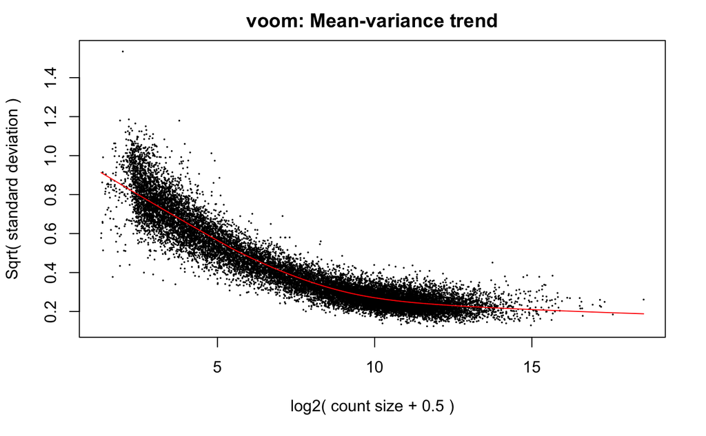

```r
v.DGE <-
  voom(rawGeneCountTable.DGE.filt, design.matrix, plot = TRUE)
```

```r
vfit.DGE <-
  lmFit(v.DGE, design.matrix) # linear modelling;
# uses the normalised expression values on the log2 scale (calculated by voom)
# and the inverse variance weights (calculated by voom)
vfit.DGE <-
  contrasts.fit(vfit.DGE, contrasts = contr.matrix)
efit.DGE <-
  eBayes(vfit.DGE, proportion = 0.01) # default proportion = assumed proportion of genes that are differentially expressed
```

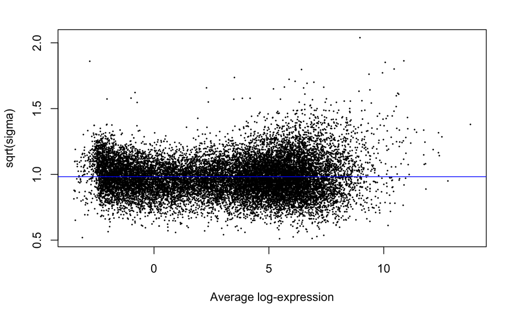

```r
plotSA(efit.DGE) # heteroscedascity removed
```

# Differentially expressed genes

## Summary

- Control FDR (Benjamini-Hochberg FDR at 5 %). Using method “separate” in this case - “global” is more stringent as it effectively would the a multiple comparison across 5x ~18000 genes instead of 1x only = correcting for multiple comparisons within each contrast rather than globally.

```r
summary(decideTests(efit.DGE, method = "separate"))
```

```
       KO_INH1 KO_INH2 WT_INH1 WT_INH2 KOvsWT
Down      3512      92    3181       4   5333
NotSig   11039   17415   11523   17611   7202
Up        3085     129    2932      21   5101
```

- Test effect of ‘magnitude’ of differential expression by varying fold-change cut-off

```r
summary(decideTests(efit.DGE, method = "separate", lfc=log2(2)))
```

```
       KO_INH1 KO_INH2 WT_INH1 WT_INH2 KOvsWT
Down        69       2      94       0    581
NotSig   17287   17632   17263   17636  16155
Up         280       2     279       0    900
```

```r
summary(decideTests(efit.DGE, method = "separate", lfc=log2(1.3)))
```

```
       KO_INH1 KO_INH2 WT_INH1 WT_INH2 KOvsWT
Down       689      22     659       0   1912
NotSig   15488   17599   15589   17630  13156
Up        1459      15    1388       6   2568
```